# Get SOE stock status indicator from assessment data

Sarah Gaichas

10 December, 2020

## The old way

I searched for each assessment document and filled in this spreadsheet by hand. Time consuming and error prone.

```r
datatable(read.csv(here("2019assess.csv")), rownames = FALSE, options = list(scrollX = TRUE))
```

| No | Entity.Name | Science.Center | Assessment.Year | Last.Data.Year | Assessment.Level | Citation | Comments | Best.F | F.Year | Flimit | Fmsy | F.Flimit | F.Fmsy | Best.B | B.Year | B.Blimit | B.Bmsy | Stock.Level.Relative.to.Bmsy | Bmsy | Blim |
| --- | --- | --- | --- | --- | --- | --- | --- | --- | --- | --- | --- | --- | --- | --- | --- | --- | --- | --- | --- | --- |
| 1 | Atlantic mackerel - Gulf of Maine / Cape Hatteras | NEFSC | 1999 | 1998 | 4 | SARC 30 Report (1999) |  |  |  |  |  |  |  |  |  |  |  |  |  |  |
| 2 | Atlantic mackerel - Gulf of Maine / Cape Hatteras | NEFSC | 2005 | 2004 | 4 | SARC 42 Report (2006) |  |  |  |  |  | 0.31 |  |  |  |  | 3.57 |  |  |  |
| 3 | Atlantic mackerel - Gulf of Maine / Cape Hatteras | NEFSC | 2010 | 2008 | 4 | TRAC Status Report 2010/01 | B &amp; F values are indicative of trend only within the context of their time series. BRPs were computed but rejected |  | 2008 |  |  |  |  |  | 2008 |  |  | UNKNOWN |  |  |
| 4 | Atlantic mackerel - Gulf of Maine / Cape Hatteras | NEFSC | 2017 | 2016 |  | SARC 64 Assessment Summary |  | 0.47 | 2016 | 0.26 | 0.26 | 1.807692308 | 1.807692308 | 43519 | 2016 |  | 0.442055116 |  | 98447 |  |
| 5 | Butterfish - Gulf of Maine / Cape Hatteras | NEFSC | 2003 | 2002 | 2 | SARC 38 Report (2004) |  |  |  |  |  |  |  |  |  |  |  |  |  |  |
| 6 | Butterfish - Gulf of Maine / Cape Hatteras | NEFSC | 2009 | 2008 | 4 | NEFSC CRD 10-01 (2010) |  | 0.02 | 2008 |  |  |  |  | 45000 | 2008 |  |  | UNKNOWN |  |  |
| 7 | Butterfish - Gulf of Maine / Cape Hatteras | NEFSC | 2014 | 2012 | 5 | NEFSC CRD 14-03 (2014) | The 2014 assessment was accepted. It was based on a new model, and produced new stock status. Status was formerly unknown, but is now improved to: not overfishing, not overfished, and rebuilt. In addi… | 0.02 | 2012 | 0.81 | 0.81 | 0.025 | 0.025 | 79451 | 2012 | 3.483 | 1.742 | ABOVE |  |  |
| 8 | Butterfish - Gulf of Maine / Cape Hatteras |  | 2017 |  |  | Butterfish 2017 SA update |  | 0.05 | 2016 | 0.81 | 0.81 | 0.061728395 | 0.061728395 | 64376 | 2016 | 2.822518415 | 1.411259207 |  |  |  |
| 9 | Longfin inshore squid - Georges Bank / Cape Hatteras | NEFSC | 2001 | 2000 | 3 | SARC 33 Report (2001) |  |  |  |  |  |  |  |  |  |  |  |  |  |  |
| 10 | Longfin inshore squid - Georges Bank / Cape Hatteras | NEFSC | 2011 | 2009 | 1 | NEFSC CRD 11-01 (2011) |  | 0.176 | 2009 |  |  |  |  | 54442 | 2009 | 2.568 | 1.284 | ABOVE |  |  |

[output cut: 314 more lines]

## The new way

Andy made the [assessmentdata package](https://github.com/NOAA-EDAB/assessmentdata) based on [Stock SMART](https://www.st.nmfs.noaa.gov/stocksmart?app=homepage). Surely this will be better?

Two data frames are in the package, `stockAssessmentData` and `stockAssessmentSummary`.

In `stockAssessmentData` we have time series. Columns are Species, Region, Year, Value, Metric, Description, Units, AssessmentYear and the reported metrics are Catch, Fmort, Recruitment, Abundance, Index.

```r
datatable(head(stockAssessmentData), rownames = FALSE)
```

| Species | Region | Year | Value | Metric | Description | Units | AssessmentYear |
| --- | --- | --- | --- | --- | --- | --- | --- |
| Acadian redfish | Gulf of Maine / Georges Bank | 1913 | 7 | Catch | Reported Catch - Total (Mean) | Metric Tons | 2017 |
| Acadian redfish | Gulf of Maine / Georges Bank | 1914 | 30 | Catch | Reported Catch - Total (Mean) | Metric Tons | 2017 |
| Acadian redfish | Gulf of Maine / Georges Bank | 1915 | 40 | Catch | Reported Catch - Total (Mean) | Metric Tons | 2017 |
| Acadian redfish | Gulf of Maine / Georges Bank | 1916 | 53 | Catch | Reported Catch - Total (Mean) | Metric Tons | 2017 |
| Acadian redfish | Gulf of Maine / Georges Bank | 1917 | 82 | Catch | Reported Catch - Total (Mean) | Metric Tons | 2017 |
| Acadian redfish | Gulf of Maine / Georges Bank | 1918 | 73 | Catch | Reported Catch - Total (Mean) | Metric Tons | 2017 |

In `stockAssessmentSummary` we have assessment metadata. Columns are Stock Name, Jurisdiction, FMP, Science Center, Regional Ecosystem, FSSI Stock?, ITIS Taxon Serial Number, Scientific Name, Common Name, Stock Area, Assessment Year, Assessment Month, Last Data Year, Update Type, Review Result, Assessment Model, Model Version, Lead Lab, Citation, Final Assessment Report 1, Final Assessment Report 2, Point of Contact, Life History Data, Abundance Data, Catch Data, Assessment Level, Assessment Frequency, Assessment Type, Model Category, Catch Input Data, Abundance Input Data, Biological Input Data, Ecosystem Linkage, Composition Input Data, F Year, Estimated F, F Unit, F Basis, Flimit, Flimit Basis, Fmsy, Fmsy Basis, F/Flimit, F/Fmsy, Ftarget, Ftarget Basis, F/Ftarget, B Year, Estimated B, B Unit, B Basis, Blimit, Blimit Basis, Bmsy, Bmsy Basis, B/Blimit, B/Bmsy, MSY, MSY Unit.

```r
datatable(head(stockAssessmentSummary), rownames = FALSE, options = list(scrollX = TRUE))
```

| Stock Name | Jurisdiction | FMP | Science Center | Regional Ecosystem | FSSI Stock? | ITIS Taxon Serial Number | Scientific Name | Common Name | Stock Area | Assessment Year | Assessment Month | Last Data Year | Update Type | Review Result | Assessment Model | Model Version | Lead Lab | Citation | Final Assessment Report 1 | Final Assessment Report 2 | Point of Contact | Life History Data | Abundance Data | Catch Data | Assessment Level | Assessment Frequency | Assessment Type | Model Category | Catch Input Data | … |
| --- | --- | --- | --- | --- | --- | --- | --- | --- | --- | --- | --- | --- | --- | --- | --- | --- | --- | --- | --- | --- | --- | --- | --- | --- | --- | --- | --- | --- | --- | --- |
| Cobia - Southern Atlantic Coast | ASMFC | ASMFC Not In FMP | SEFSC | Southeast Shelf | N | 168566 | Rachycentron canadum | Cobia | Southern Atlantic Coast | 2013 | 4 | 2011 | Benchmark | Full acceptance | BAM | Cobia | NMFS-SEFSC, Beaufort Lab | SEDAR 28, South Atlantic Cobia, January, 2013 (http://www.sefsc.noaa.gov/sedar/download/S28_SAR_SACobia_Final_1.9.2013.pdf?id=DOCUMENT) | South Atlantic Cobia |  | Kevin Craig | 2 | 1 | 4 | 4 | 1 |  |  |  | … |
| Albacore - North Atlantic | Atlantic HMS | Consolidated Atlantic Highly Migratory Species | SEFSC | Atlantic Highly Migratory | N | 172419 | Thunnus alalunga | Albacore | North Atlantic | 2007 | 7 | 2005 | Full Update | Full acceptance | MultifanCL |  | ICCAT-SCRS | http://www.iccat.int/Documents/Meetings/Docs/2007_ALB%20STOCK%20ASSESS%20REP_AUG_07.pdf | REPORT OF THE 2007 ICCAT ALBACO RE STOCK ASSESSMENT SESSION |  | Victor Restrepo | 2 | 1 | 2 | 4 | 2 |  |  |  | … |
| Albacore - North Atlantic | Atlantic HMS | Consolidated Atlantic Highly Migratory Species | SEFSC | Atlantic Highly Migratory | N | 172419 | Thunnus alalunga | Albacore | North Atlantic | 2013 | 10 | 2011 | Full Update | Full acceptance | Multifan CL |  | ICCAT-SCRS | http://www.iccat.int/Documents/Meetings/Docs/2013_ALB_ASSESS_REP_ENG.pdf |  |  | Michael Schirripa, Craig Brown | 3 | 1 | 2 | 4 | 2 |  |  |  | … |
| Albacore - North Atlantic | Atlantic HMS | Consolidated Atlantic Highly Migratory Species | SEFSC | Atlantic Highly Migratory | N | 172419 | Thunnus alalunga | Albacore | North Atlantic | 2016 | 10 | 2015 | Full Update | Full acceptance | Aspic |  | ICCAT-SCRS | http://iccat.es/Documents/Meetings/Docs/2016_ALB_REPORT_ENG.pdf | Albacore 2016 Assessment Report |  | Rishi Sharma, Craig Brown | 3 | 1 | 1 | 3 | 2 |  |  |  | … |
| Atlantic Small Coastal Shark Complex | Atlantic HMS | Consolidated Atlantic Highly Migratory Species | SEFSC | Atlantic Highly Migratory | N |  |  |  |  | 2007 | 11 | 2005 | Benchmark | Full acceptance | BSP (Bayesian Surplus Production) model |  | Panama City Laboratory (SEFSC) | SEDAR 13 Stock assessment report. Small Coastal Shark complex, Atlantic sharpnose, blacknose, bonnethead and finetooth shark. NOAA/NMFS Highly Migratory Species Division, 1315 East-West Highway, Silve… | Small Coastal Shark Complex, Atlantic Sharpnose, Blacknose, Bonnethead, and Finetooth Shark |  | Enric Cortes | 2 | 1 | 1 | 3 | 1 |  |  |  | … |
| Atlantic sharpnose shark - Atlantic | Atlantic HMS | Consolidated Atlantic Highly Migratory Species | SEFSC | Atlantic Highly Migratory | Y | 160200 | Rhizoprionodon terraenovae | Atlantic sharpnose shark | Atlantic | 2013 | 10 | 2011 | Full Update | Partial acceptance - Status determinations only | State-space age-structured production model |  | SEFSC | SEDAR 34 Stock Assessment Report: HMS Atlantic sharpnose shark . DOC/NOAA/NMFS SEDAR, 4055 Faber Place Drive, Suite 201, North Charleston, SC 29405 (Last accessed 11/15/2013) Available at http://www.s… |  |  | Dean Courtney, Xinsheng Zhang, Enric Cortes | 2 | 1 | 1 | 4 | 2 |  |  |  | … |

Trying to rebuild my spreadsheet from `stockAssessmentSummary` and use the ecodata code to make the dataset:

```r
test2019assess <- stockAssessmentSummary %>%
  filter(`Science Center` == "NEFSC") %>%
  select(c(`Stock Name`, Jurisdiction, FMP, `Science Center`,
           `Stock Area`, `Assessment Year`, `Last Data Year`,
           `F Year`, `Estimated F`, Flimit, Fmsy, `F/Flimit`,
           `F/Fmsy`, Ftarget, `F/Ftarget`, `B Year`, `Estimated B`,
           `B Unit`, Blimit, Bmsy, `B/Blimit`, `B/Bmsy`)) %>%
  arrange(Jurisdiction, `Stock Name`, FMP, `Assessment Year`) %>%
  rename(Entity.Name = `Stock Name`,
         Assessment.Year = `Assessment Year`,
         F.Fmsy = `F/Fmsy`,
         B.Bmsy = `B/Bmsy`)

write.csv(test2019assess, here("stockSMART2019assess.csv"))

# from get_stocks.R, ecodata 2020
  #assess <- read.csv(file.path(data.dir, "2019assess.csv"))
  assess <- test2019assess
  #decode <- read.csv(file.path(data.dir, "2019decoder.csv"))
  decode <- read.csv(here("2019decoder.csv"))

stock_status_stockSMART <-
    assess %>%
    dplyr::group_by(Entity.Name) %>%
    dplyr::filter(Assessment.Year == max(Assessment.Year)) %>%
  #Find last year assessment occurred for each stock
    dplyr::ungroup() %>%
    dplyr::left_join(.,decode, by = "Entity.Name") %>% #Join in list of managed species
    dplyr::select(Entity.Name, Assessment.Year, F.Fmsy, B.Bmsy, Council, Code) %>%
  #select column variables to keep
    dplyr::mutate(id = 1:length(Entity.Name)) %>%
    tidyr::gather(.,Var, Value,-id,-Entity.Name,-Assessment.Year,-Council,-Code) %>%
  #wide to long
    dplyr::select(-id) %>%
    dplyr::rename(`Last assessment` = Assessment.Year,
                  Stock = Entity.Name) %>% #rename variables for clarity
    dplyr::mutate(Units = "unitless") %>%
    dplyr::mutate(Value = replace(Value, which(Code == "N Windowpane" & Var == "F.Fmsy"), NA))
```

Then test to see if I get the same plot for assessments up to Dec 2019 I got the old way.

### Comparisons

#### StockSMART source, Mid-Atlantic

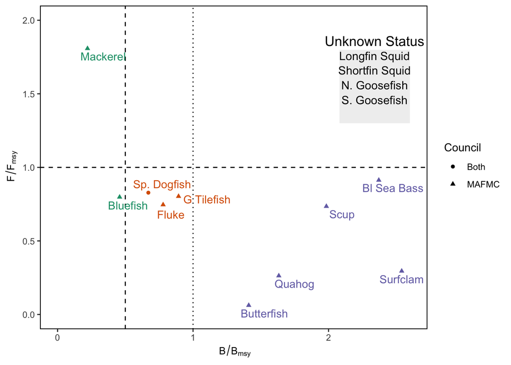

```r
stock_status <-
  stock_status_stockSMART %>%
  mutate(Code = recode(Code, "Dogfish" = "Sp. Dogfish" )) %>%
  spread(.,Var,Value) %>%
  filter(Council %in% c("MAFMC","Both")) %>%
  group_by(Stock) %>%
  mutate(score = case_when(
    (B.Bmsy <0.5) ~"a",
    (F.Fmsy >1) ~ "a",
    (F.Fmsy < 1 & B.Bmsy > 0.5 & B.Bmsy < 1) ~ "b",
    (F.Fmsy < 1 & B.Bmsy > 1) ~ "c"))
#Plot constants
y.max <- 2.0 #1.75 mackerel cut off F/Fmsy is 1.8
x.max <- 2.6
#A dataframe that defines custom legend for stocks with unknown status
unknown <- data.frame(text = c("Unknown Status", "Longfin Squid",
                              "Shortfin Squid", "N. Goosefish", "S. Goosefish"),
                    x = rep(0.9*x.max,5), y = seq(0.93*y.max,1.4,-.1))

# Custom Color
custom_color<- c("#56B4E9", "#009E73", "#0072B2")
#Plotting code
ggplot(data = stock_status) +
  geom_vline(xintercept = 1, linetype = "dotted")+
  geom_vline(xintercept = 0.5, linetype = "dashed")+
  geom_hline(yintercept = 1, linetype = "dashed") +
  geom_point(aes(x = B.Bmsy,
                 y = F.Fmsy,
                 shape = Council,
                 color = score)) +
  geom_text_repel(aes(x = B.Bmsy, #geom_text_repel auto-jitters text around points
                      y = F.Fmsy,
                      label = Code,
                      color = score),
                  show.legend = FALSE, nudge_y = -0.01, nudge_x = 0.05) +
  scale_color_brewer(palette = "Dark2",
                     breaks = stock_status$score) +
  ylim(0,y.max) +
  xlim(0,x.max) +
  geom_text(data = unknown, aes(x = x, y = y, label = text), #Custom legend for unknown stock status
            size = c(4.75,rep(4,4))) +
  annotate("rect", xmin = 0.8*x.max,
           xmax = x.max,
           ymin = 0.65*y.max,
           ymax = 0.90*y.max,
           alpha = 0.1) +
  xlab(expression(~B/B[msy])) +
  ylab(expression(~F/F[msy])) +
  guides(color = FALSE) +
  theme_ts()
```

#### SOE 2020 ecodata source, Mid-Atlantic

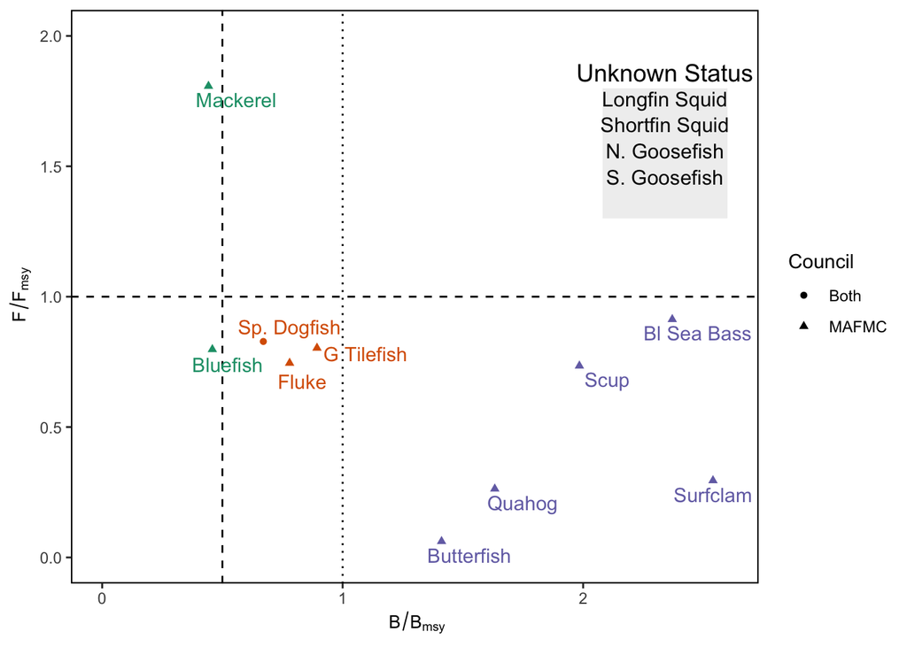

```r
stock_status <-
  ecodata::stock_status %>%
  mutate(Code = recode(Code, "Dogfish" = "Sp. Dogfish" )) %>%
  spread(.,Var,Value) %>%
  filter(Council %in% c("MAFMC","Both")) %>%
  group_by(Stock) %>%
  mutate(score = case_when(
    (B.Bmsy <0.5) ~"a",
    (F.Fmsy >1) ~ "a",
    (F.Fmsy < 1 & B.Bmsy > 0.5 & B.Bmsy < 1) ~ "b",
    (F.Fmsy < 1 & B.Bmsy > 1) ~ "c"))
#Plot constants
y.max <- 2.0 #1.75 mackerel cut off F/Fmsy is 1.8
x.max <- 2.6
#A dataframe that defines custom legend for stocks with unknown status
unknown <- data.frame(text = c("Unknown Status", "Longfin Squid",
                              "Shortfin Squid", "N. Goosefish", "S. Goosefish"),
                    x = rep(0.9*x.max,5), y = seq(0.93*y.max,1.4,-.1))

# Custom Color
custom_color<- c("#56B4E9", "#009E73", "#0072B2")
#Plotting code
ggplot(data = stock_status) +
  geom_vline(xintercept = 1, linetype = "dotted")+
  geom_vline(xintercept = 0.5, linetype = "dashed")+
  geom_hline(yintercept = 1, linetype = "dashed") +
  geom_point(aes(x = B.Bmsy,
                 y = F.Fmsy,
                 shape = Council,
                 color = score)) +
  geom_text_repel(aes(x = B.Bmsy, #geom_text_repel auto-jitters text around points
                      y = F.Fmsy,
                      label = Code,
                      color = score),
                  show.legend = FALSE, nudge_y = -0.01, nudge_x = 0.05) +
  scale_color_brewer(palette = "Dark2",
                     breaks = stock_status$score) +
  ylim(0,y.max) +
  xlim(0,x.max) +
  geom_text(data = unknown, aes(x = x, y = y, label = text), #Custom legend for unknown stock status
            size = c(4.75,rep(4,4))) +
  annotate("rect", xmin = 0.8*x.max,
           xmax = x.max,
           ymin = 0.65*y.max,
           ymax = 0.90*y.max,
           alpha = 0.1) +
  xlab(expression(~B/B[msy])) +
  ylab(expression(~F/F[msy])) +
  guides(color = FALSE) +
  theme_ts()
```

#### StockSMART source, New England

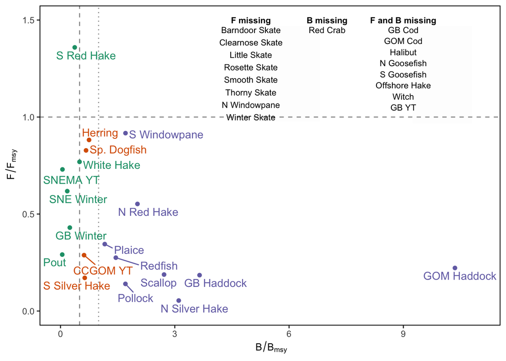

```r
stock_status <- stock_status_stockSMART %>%
  mutate(Code = recode(Code, "Dogfish" = "Sp. Dogfish" )) %>%
  spread(.,Var,Value) %>%
  filter(Council %in% c("NEFMC","Both")) %>%
  group_by(Stock) %>%
  mutate(score = case_when(
    (B.Bmsy <0.5) ~"a",
    (F.Fmsy >1) ~ "a",
    (F.Fmsy < 1 & B.Bmsy > 0.5 & B.Bmsy < 1) ~ "b",
    (F.Fmsy < 1 & B.Bmsy > 1) ~ "c"))
#Plot constants
y.max <- 1.5
x.max <- 10
all_missing <- stock_status %>%
  filter(is.na(B.Bmsy),is.na(F.Fmsy)) %>%
  dplyr::select(Code, Council)
b_missing <- stock_status %>%
  filter(is.na(B.Bmsy), !is.na(F.Fmsy)) %>%
  dplyr::select(Code, Council)
f_missing <- stock_status %>%
  filter(is.na(F.Fmsy), !is.na(B.Bmsy)) %>%
  dplyr::select(Code, Council)
#A dataframe that defines custom legend for stocks with unknown status
all.df <- data.frame(text = all_missing$Code,
                    x = rep(x.max*0.9,length(all_missing$Code)),
                    #y = seq(1.45,1.05, length.out = 7))
                    y = seq(1.45,1.05, length.out = 8))
b.df <- data.frame(text = b_missing$Code,
                    x = rep(x.max*0.7,length(b_missing$Code)),
                    y = c(1.45,2.15))
f.df <- data.frame(text = f_missing$Code,
                    x = rep(x.max*0.5,length(f_missing$Code)),
                    y = seq(1.45,1.0, length.out = 8))

#Plotting code
ggplot(data = stock_status) +
  geom_vline(xintercept = 1, linetype = "dotted", color = "grey60")+
  geom_vline(xintercept = 0.5, linetype = "dashed", color = "grey60")+
  geom_hline(yintercept = 1, linetype = "dashed", color = "grey60") +
  geom_point(aes(x = B.Bmsy,
                 y = F.Fmsy,
                 color = stock_status$score)) +
  geom_text_repel(aes(x = B.Bmsy, #geom_text_repel auto-jitters text around points
                      y = F.Fmsy,
                      label = Code,
                      color = stock_status$score), show.legend = FALSE,nudge_y = -0.01, nudge_x = 0.05) +
  ylim(0,y.max) +
  xlim(0,x.max*1.1) +
  geom_text(data = all.df, aes(x = x, y = y, label = text),show.legend = FALSE, size = 3)+
  geom_text(data = b.df, aes(x = x, y = y, label = text),show.legend = FALSE, size = 3)+
  geom_text(data = f.df, aes(x = x, y = y, label = text),show.legend = FALSE, size = 3)+
  scale_color_brewer(palette = "Dark2", #Change legend labels for clarity
                     breaks = stock_status$score) +
  annotate("rect", xmin = 0.924*x.max,
           xmax = 1.08*x.max,
           ymin = 0.645*y.max,
           ymax = 0.98*y.max,
           alpha = 0.01) +
  annotate("text", x = 9, y = 1.5, label = "F and B missing", fontface =2, size = 3)+
  annotate("rect",
             xmin = 0.70*x.max,
             xmax = 0.85*x.max,
             ymin = 0.90*y.max,
             ymax = 1.8,
             alpha = 0.01) +
  annotate("text", x = 7, y = 1.5, label = "B missing", fontface =2, size = 3)+
  annotate("rect", xmin = 0.509*x.max,
           xmax = 0.681*x.max,
           ymin = 0.65*y.max,
           ymax = 0.98*y.max,
           alpha = 0.01) +
  annotate("text", x = 5, y = 1.5, label = "F missing", fontface =2, size = 3)+
  xlab(expression(~B/B[msy])) +
  ylab(expression(~F/F[msy])) +
  guides(color = FALSE) +
  theme_ts()
```

#### SOE 2020 ecodata source, New England

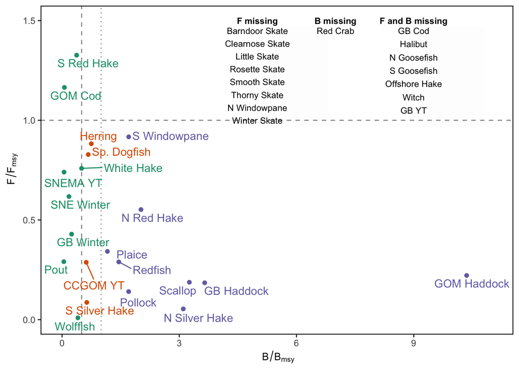

```r
stock_status <- ecodata::stock_status %>%
  mutate(Code = recode(Code, "Dogfish" = "Sp. Dogfish" )) %>%
  spread(.,Var,Value) %>%
  filter(Council %in% c("NEFMC","Both")) %>%
  group_by(Stock) %>%
  mutate(score = case_when(
    (B.Bmsy <0.5) ~"a",
    (F.Fmsy >1) ~ "a",
    (F.Fmsy < 1 & B.Bmsy > 0.5 & B.Bmsy < 1) ~ "b",
    (F.Fmsy < 1 & B.Bmsy > 1) ~ "c"))
#Plot constants
y.max <- 1.5
x.max <- 10
all_missing <- stock_status %>%
  filter(is.na(B.Bmsy),is.na(F.Fmsy)) %>%
  dplyr::select(Code, Council)
b_missing <- stock_status %>%
  filter(is.na(B.Bmsy), !is.na(F.Fmsy)) %>%
  dplyr::select(Code, Council)
f_missing <- stock_status %>%
  filter(is.na(F.Fmsy), !is.na(B.Bmsy)) %>%
  dplyr::select(Code, Council)
#A dataframe that defines custom legend for stocks with unknown status
all.df <- data.frame(text = all_missing$Code,
                    x = rep(x.max*0.9,length(all_missing$Code)),
                    y = seq(1.45,1.05, length.out = 7))
b.df <- data.frame(text = b_missing$Code,
                    x = rep(x.max*0.7,length(b_missing$Code)),
                    y = c(1.45,2.15))
f.df <- data.frame(text = f_missing$Code,
                    x = rep(x.max*0.5,length(f_missing$Code)),
                    y = seq(1.45,1.0, length.out = 8))

#Plotting code
ggplot(data = stock_status) +
  geom_vline(xintercept = 1, linetype = "dotted", color = "grey60")+
  geom_vline(xintercept = 0.5, linetype = "dashed", color = "grey60")+
  geom_hline(yintercept = 1, linetype = "dashed", color = "grey60") +
  geom_point(aes(x = B.Bmsy,
                 y = F.Fmsy,
                 color = stock_status$score)) +
  geom_text_repel(aes(x = B.Bmsy, #geom_text_repel auto-jitters text around points
                      y = F.Fmsy,
                      label = Code,
                      color = stock_status$score), show.legend = FALSE,nudge_y = -0.01, nudge_x = 0.05) +
  ylim(0,y.max) +
  xlim(0,x.max*1.1) +
  geom_text(data = all.df, aes(x = x, y = y, label = text),show.legend = FALSE, size = 3)+
  geom_text(data = b.df, aes(x = x, y = y, label = text),show.legend = FALSE, size = 3)+
  geom_text(data = f.df, aes(x = x, y = y, label = text),show.legend = FALSE, size = 3)+
  scale_color_brewer(palette = "Dark2", #Change legend labels for clarity
                     breaks = stock_status$score) +
  annotate("rect", xmin = 0.924*x.max,
           xmax = 1.08*x.max,
           ymin = 0.645*y.max,
           ymax = 0.98*y.max,
           alpha = 0.01) +
  annotate("text", x = 9, y = 1.5, label = "F and B missing", fontface =2, size = 3)+
  annotate("rect",
             xmin = 0.70*x.max,
             xmax = 0.85*x.max,
             ymin = 0.90*y.max,
             ymax = 1.8,
             alpha = 0.01) +
  annotate("text", x = 7, y = 1.5, label = "B missing", fontface =2, size = 3)+
  annotate("rect", xmin = 0.509*x.max,
           xmax = 0.681*x.max,
           ymin = 0.65*y.max,
           ymax = 0.98*y.max,
           alpha = 0.01) +
  annotate("text", x = 5, y = 1.5, label = "F missing", fontface =2, size = 3)+
  xlab(expression(~B/B[msy])) +
  ylab(expression(~F/F[msy])) +
  guides(color = FALSE) +
  theme_ts()
```

### Issues

Mid-Atlantic: Mackerel B.Bmsy is different, lower in stockSMART. New England: GOM Cod called F and B missing in stockSMART. Hakes are different. Wolffish missing from stockSMART?

Comparing the 2019assess.csv with the stockSMART2019assess.csv, discrepancies are:

1. Mackerel is correct in stockSMART. The 2019assess.csv spreadsheet has Blimit entered where Bmsy should be.

### Next…

Then apply for assessments up to Dec 2020. Well, max assessment year is 2019, so I guess I still need to fill this in by hand!

Options:

1. Retain only the fields used by get_stocks.R so maybe I don’t break ecodata.
2. Recreate the entire spreadsheet for all assessments (means they must all be in stocksmart).

#### Decisions

- Update with stockSMART for 2019 and prior records, add only the 2020 assessments by hand. (Is stockSMART the definitive source of status information?)
- Recreate assess spreadsheet fields from stockSMART including all fields to act as metadata

```r
new2019assess <- stockAssessmentSummary %>%
  filter(`Science Center` == "NEFSC") %>%
  rename(Entity.Name = `Stock Name`) %>%
  rename_all(list(~make.names(.)))
```

- Add 2020 assessments using a script here rather than typing into a spreadsheet

```r
#subset stockSMARTsummary for updates species
  #add a row for each species with an update, copying most recent data
  #update Assessment.Year = 2020
  #update all other fields--nope just got them already compiled!

# updatespecies <- new2019assess %>%
#   filter(str_detect(Entity.Name, c("redfish|halibut|herring|scallop|surfclam|wolffish|Butterfish|Longfin|pout|quahog|Red hake|Silver hake|Windowpane|Winter flounder"))) %>%
#   group_by(Entity.Name) %>%
#   do(add_row(., Assessment.Year = 2020)) %>%
#   ungroup() %>%
#   fill(!c(Assessment.Year, Assessment.Month, Last.Data.Year,
#           Update.Type, Review.Result, Assessment.Model, Model.Version,
#           Citation:MSY.Unit))

prelim2020 <- read.csv(here("NE Stock Assessment Results.csv")) %>%
  filter(Assessment.Year == 2020) %>%
  rename(Entity.Name = Stock,
         FSSI.Stock. = FSSI,
         Estimated.F = Best.F,
         Estimated.B = Best.B,
         Review.Result = Review.Type) %>%
  select(-c(Year, Status.Stock., Record.Status, TimeSeries.Data.,
            Survey.Links., Adequate, Minimum.F, Maximum.F,
            Minimum.B, Maximum.B,
            Stock.Level.Relative.to.Bmsy:Decision.memo.related.to.inadequate.rebuilding.progress))


update2020assess <- bind_rows(new2019assess, prelim2020)

write.csv(update2020assess, here("2020assess.csv"))
```

- Retain only Entity.Name, Council, and Code fields (used by `get_stocks`) in decoder

```r
newdecoder <- read.csv(here("2019decoder.csv")) %>%
  select(Entity.Name, Code, Council)

write.csv(newdecoder, here("2020decoder.csv"))
```

#### 2020 stock assessment source

Used the form here: https://apps-nefsc.fisheries.noaa.gov/saw/sasi/sasi_report_options.php

Files should be up-to-date as of the day of my query, December 9, 2020, according to the website.

Checked the boxes: Year–2020

Checked each available 2020 species and stock area in turn, downloaded .zip of “all files”.

Species with 2020 updates: Acadian redfish, Atlantic halibut, Atlantic herring, Atlantic Sea Scallop, Atlantic surfclam, Atlantic wolffish, Butterfish, Longfin squid, Ocean Pout, Ocean quahog, Red Hake (2 stocks), Silver hake (2 stocks), Windowpane flounder (2 stocks), Winter flounder (3 stocks).

**Update:** these results were compiled as preliminary information by Jeff Vieser, who is awaiting final NEFSC publication to post to stockSMART. He sent me the spreadsheet `NE Stock Assessment Results.xlsx` 10 December 2020. We will mark these preliminary, pending final number confirmation.

I will spot check the spreadsheet to ensure it matches numbers in the downloaded reports.

### New Plots with *preliminary* 2020 assessment results

```r
# from get_stocks.R, ecodata 2020
  #assess <- read.csv(file.path(data.dir, "2019assess.csv"))
  #decode <- read.csv(file.path(data.dir, "2019decoder.csv"))
  assess <- read.csv(here("2020assess.csv"))
  decode <- read.csv(here("2020decoder.csv"))

stock_status_2020 <-
    assess %>%
    dplyr::group_by(Entity.Name) %>%
    dplyr::filter(Assessment.Year == max(Assessment.Year)) %>%
  #Find last year assessment occurred for each stock
    dplyr::ungroup() %>%
    dplyr::left_join(.,decode, by = "Entity.Name") %>% #Join in list of managed species
    dplyr::select(Entity.Name, Assessment.Year, F.Fmsy, B.Bmsy, Council, Code) %>%
  #select column variables to keep
    dplyr::mutate(id = 1:length(Entity.Name)) %>%
    tidyr::gather(.,Var, Value,-id,-Entity.Name,-Assessment.Year,-Council,-Code) %>%
  #wide to long
    dplyr::select(-id) %>%
    dplyr::rename(`Last assessment` = Assessment.Year,
                  Stock = Entity.Name) %>% #rename variables for clarity
    dplyr::mutate(Units = "unitless") %>%
    dplyr::mutate(Value = replace(Value, which(Code == "N Windowpane" & Var == "F.Fmsy"), NA))
```

#### StockSMART source, Mid-Atlantic

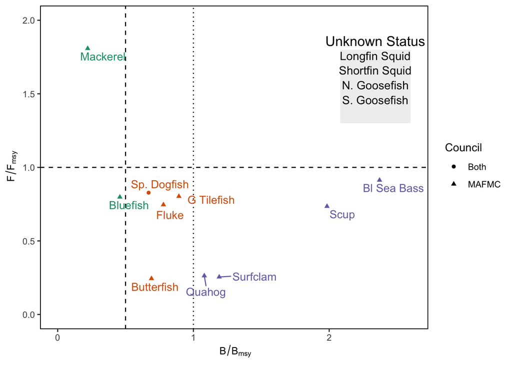

```r
stock_status <-
  stock_status_2020 %>%
  mutate(Code = recode(Code, "Dogfish" = "Sp. Dogfish" )) %>%
  spread(.,Var,Value) %>%
  filter(Council %in% c("MAFMC","Both")) %>%
  group_by(Stock) %>%
  mutate(score = case_when(
    (B.Bmsy <0.5) ~"a",
    (F.Fmsy >1) ~ "a",
    (F.Fmsy < 1 & B.Bmsy > 0.5 & B.Bmsy < 1) ~ "b",
    (F.Fmsy < 1 & B.Bmsy > 1) ~ "c"))
#Plot constants
y.max <- 2.0 #1.75 mackerel cut off F/Fmsy is 1.8
x.max <- 2.6
#A dataframe that defines custom legend for stocks with unknown status
unknown <- data.frame(text = c("Unknown Status", "Longfin Squid",
                              "Shortfin Squid", "N. Goosefish", "S. Goosefish"),
                    x = rep(0.9*x.max,5), y = seq(0.93*y.max,1.4,-.1))

# Custom Color
custom_color<- c("#56B4E9", "#009E73", "#0072B2")
#Plotting code
ggplot(data = stock_status) +
  geom_vline(xintercept = 1, linetype = "dotted")+
  geom_vline(xintercept = 0.5, linetype = "dashed")+
  geom_hline(yintercept = 1, linetype = "dashed") +
  geom_point(aes(x = B.Bmsy,
                 y = F.Fmsy,
                 shape = Council,
                 color = score)) +
  geom_text_repel(aes(x = B.Bmsy, #geom_text_repel auto-jitters text around points
                      y = F.Fmsy,
                      label = Code,
                      color = score),
                  show.legend = FALSE, nudge_y = -0.01, nudge_x = 0.05) +
  scale_color_brewer(palette = "Dark2",
                     breaks = stock_status$score) +
  ylim(0,y.max) +
  xlim(0,x.max) +
  geom_text(data = unknown, aes(x = x, y = y, label = text), #Custom legend for unknown stock status
            size = c(4.75,rep(4,4))) +
  annotate("rect", xmin = 0.8*x.max,
           xmax = x.max,
           ymin = 0.65*y.max,
           ymax = 0.90*y.max,
           alpha = 0.1) +
  xlab(expression(~B/B[msy])) +
  ylab(expression(~F/F[msy])) +
  guides(color = FALSE) +
  theme_ts()
```

#### StockSMART source, New England

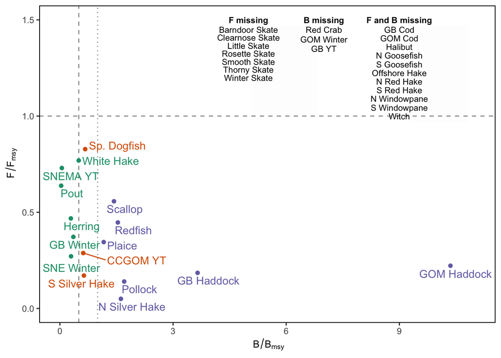

```r
stock_status <-
  stock_status_2020 %>%
  mutate(Code = recode(Code, "Dogfish" = "Sp. Dogfish" )) %>%
  spread(.,Var,Value) %>%
  filter(Council %in% c("NEFMC","Both")) %>%
  group_by(Stock) %>%
  mutate(score = case_when(
    (B.Bmsy <0.5) ~"a",
    (F.Fmsy >1) ~ "a",
    (F.Fmsy < 1 & B.Bmsy > 0.5 & B.Bmsy < 1) ~ "b",
    (F.Fmsy < 1 & B.Bmsy > 1) ~ "c"))
#Plot constants
y.max <- 1.5
x.max <- 10
all_missing <- stock_status %>%
  filter(is.na(B.Bmsy),is.na(F.Fmsy)) %>%
  dplyr::select(Code, Council)
b_missing <- stock_status %>%
  filter(is.na(B.Bmsy), !is.na(F.Fmsy)) %>%
  dplyr::select(Code, Council)
f_missing <- stock_status %>%
  filter(is.na(F.Fmsy), !is.na(B.Bmsy)) %>%
  dplyr::select(Code, Council)
#A dataframe that defines custom legend for stocks with unknown status
all.df <- data.frame(text = all_missing$Code,
                    x = rep(x.max*0.9,length(all_missing$Code)),
                    y = seq(1.45,1.0, length.out = length(all_missing$Code)))
b.df <- data.frame(text = b_missing$Code,
                    x = rep(x.max*0.7,length(b_missing$Code)),
                    y = seq(1.45,1.35, length.out = length(b_missing$Code)))
f.df <- data.frame(text = f_missing$Code,
                    x = rep(x.max*0.5,length(f_missing$Code)),
                    y = seq(1.45,1.2, length.out = length(f_missing$Code)))

#Plotting code
ggplot(data = stock_status) +
  geom_vline(xintercept = 1, linetype = "dotted", color = "grey60")+
  geom_vline(xintercept = 0.5, linetype = "dashed", color = "grey60")+
  geom_hline(yintercept = 1, linetype = "dashed", color = "grey60") +
  geom_point(aes(x = B.Bmsy,
                 y = F.Fmsy,
                 color = stock_status$score)) +
  geom_text_repel(aes(x = B.Bmsy, #geom_text_repel auto-jitters text around points
                      y = F.Fmsy,
                      label = Code,
                      color = stock_status$score), show.legend = FALSE,nudge_y = -0.01, nudge_x = 0.05) +
  ylim(0,y.max) +
  xlim(0,x.max*1.1) +
  geom_text(data = all.df, aes(x = x, y = y, label = text),show.legend = FALSE, size = 3)+
  geom_text(data = b.df, aes(x = x, y = y, label = text),show.legend = FALSE, size = 3)+
  geom_text(data = f.df, aes(x = x, y = y, label = text),show.legend = FALSE, size = 3)+
  scale_color_brewer(palette = "Dark2", #Change legend labels for clarity
                     breaks = stock_status$score) +
  annotate("rect", xmin = 0.924*x.max,
           xmax = 1.08*x.max,
           ymin = 0.645*y.max,
           ymax = 0.98*y.max,
           alpha = 0.01) +
  annotate("text", x = 9, y = 1.5, label = "F and B missing", fontface =2, size = 3)+
  annotate("rect",
             xmin = 0.70*x.max,
             xmax = 0.85*x.max,
             ymin = 0.90*y.max,
             ymax = 1.8,
             alpha = 0.01) +
  annotate("text", x = 7, y = 1.5, label = "B missing", fontface =2, size = 3)+
  annotate("rect", xmin = 0.509*x.max,
           xmax = 0.681*x.max,
           ymin = 0.65*y.max,
           ymax = 0.98*y.max,
           alpha = 0.01) +
  annotate("text", x = 5, y = 1.5, label = "F missing", fontface =2, size = 3)+
  xlab(expression(~B/B[msy])) +
  ylab(expression(~F/F[msy])) +
  guides(color = FALSE) +
  theme_ts()
```